# Finding Similar Board Games

Phil Henrickson

2021-12-12

## What is this analysis?

This notebook is for selecting any boardgame and identifying **its most comparable games using data from boardgamegeek.com**. I use a dimension reduction method (PCA) to learn the main points of variation in data about games from boardgamegee - this gives me a vector with every game’s value on each of the principal components. To find similar games, I compute the distance between all games using the first ten principal components. I use the distance between games to determine their overall similarity. Games that are close to each other are said to be *neighbors*.

This document details a game’s 25 nearest neighbors and illustrate some of the dimensions that make the selected game and its neighbors similar.

## Game Profile: **Ark Nova**

Summary information for the selected game.

| ID | Game | Published | Player Count | Playing Time | UserRatings | Average | GeekRating | Complexity |
| --- | --- | --- | --- | --- | --- | --- | --- | --- |
| 342942 | Ark Nova | 2021 | 1-4 | 150 min | 583 | 8.49 | 6.23 | 3.76 |

Information on the game’s designers, artists, mechanics and categories. Note: designer and artist features are not used in identifying nearest neighbors.

| Publisher(s) | Designer(s) | Artist(s) | Categories | Mechanics |
| --- | --- | --- | --- | --- |
| White Goblin Games | Mathias Wigge | Loïc Billiau | Economic | Tile Placement |
| Korea Boardgames Co Ltd |  | Dennis Lohausen | Environmental | Set Collection |
| Cranio Creations |  | Steffen Bieker | Animals | Variable Player Powers |
| Feuerland Spiele |  |  |  | Hexagon Grid |
| Super Meeple |  |  |  | Hand Management |
| Capstone Games |  |  |  | Card Drafting |
|  |  |  |  | Solo Solitaire Game |
|  |  |  |  | End Game Bonuses |
|  |  |  |  | Variable Setup |
|  |  |  |  | Income |

For the full profile of the selected game, go to https://boardgamegeek.com/boardgame/342942

## Most Similar Games to **Ark Nova**

The table below displays the most similar games to Ark Nova using data from boardgamegeek (BGG). The reported similarity score is the (squared) inverse of the Manhattan distance between two games.

**Note:** The analysis does not make use of a game’s number of ratings, average, or geek average, but instead looks only at a game’s categories, mechanics, playing time, player count, and complexity. The current approach for computing the distance weighs each component equally; I plan to explore a change to this in the future by using different measures of distance, as we would reasonably expect some components to be more important than others. I initially relied on Euclidean distance, but in tinkering with the results I have opted to go with the Manhattan distance for now.

| Rank | Similarity | Published | ID | Neighbor | BGGRating | GeekRating | Complexity |
| --- | --- | --- | --- | --- | --- | --- | --- |
| 1 | 27.38 | 2018 | 244711 | Newton | 7.60 | 7.06 | 3.40 |
| 2 | 25.16 | 2018 | 199792 | Everdell | 8.09 | 7.87 | 2.82 |
| 3 | 25.04 | 2014 | 146886 | La Granja | 7.66 | 7.32 | 3.58 |
| 4 | 24.43 | 2016 | 167791 | Terraforming Mars | 8.42 | 8.27 | 3.24 |
| 5 | 23.65 | 2015 | 182874 | Grand Austria Hotel | 7.88 | 7.60 | 3.23 |
| 6 | 23.53 | 2021 | 290618 | Wishland | 7.61 | 5.68 | 2.62 |
| 7 | 23.39 | 2017 | 216132 | Clans of Caledonia | 7.99 | 7.72 | 3.46 |
| 8 | 23.20 | 2020 | 306040 | Merv: The Heart of the Silk Road | 7.72 | 6.67 | 3.40 |
| 9 | 23.19 | 2020 | 300322 | Hallertau | 8.09 | 7.07 | 3.30 |
| 10 | 22.95 | 2021 | 310873 | Carnegie | 7.74 | 6.34 | 3.82 |
| 11 | 22.73 | 2016 | 196340 | Yokohama | 7.85 | 7.48 | 3.28 |
| 12 | 22.71 | 2021 | 309319 | Apogee | 7.03 | 5.52 | 3.67 |
| 13 | 22.69 | 2009 | 39683 | At the Gates of Loyang | 7.38 | 7.10 | 3.13 |
| 14 | 22.63 | 2019 | 283863 | The Magnificent | 7.62 | 6.67 | 3.18 |
| 15 | 22.61 | 2015 | 181687 | The Pursuit of Happiness | 7.21 | 6.73 | 2.49 |
| 16 | 22.32 | 2009 | 55600 | Shipyard | 7.35 | 6.78 | 3.50 |
| 17 | 22.15 | 2015 | 183394 | Viticulture Essential Edition | 8.06 | 7.90 | 2.89 |
| 18 | 22.09 | 2019 | 251247 | Barrage | 8.23 | 7.77 | 4.05 |
| 19 | 22.02 | 2019 | 240567 | Chocolate Factory | 7.19 | 6.23 | 2.85 |
| 20 | 21.98 | 2020 | 308765 | Praga Caput Regni | 8.13 | 7.31 | 3.72 |
| 21 | 21.92 | 2019 | 280480 | Crystal Palace | 7.61 | 6.72 | 3.80 |
| 22 | 21.90 | 2020 | 320819 | Dinner In Paris | 7.33 | 5.74 | 2.43 |
| 23 | 21.90 | 2016 | 72321 | The Networks | 7.21 | 6.80 | 2.57 |
| 24 | 21.65 | 2015 | 169794 | Haspelknecht | 7.25 | 6.39 | 3.04 |
| 25 | 21.56 | 2019 | 257066 | Sierra West | 6.88 | 6.07 | 3.09 |

## Plotting Comparable Games to **Ark Nova**

Placing the selected game and its nearest neighbors on the first two principal components.

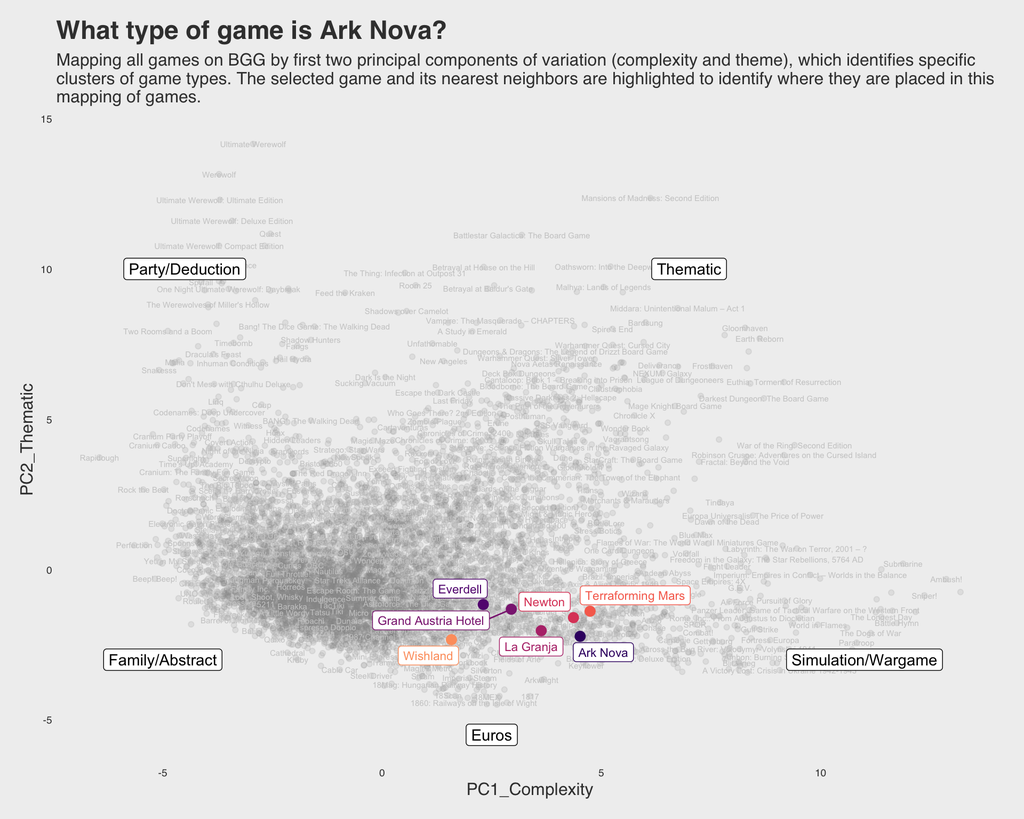

Placing games on the first four principal components, which I have found to loosely map to complexity, theme, economy, and cooperation.

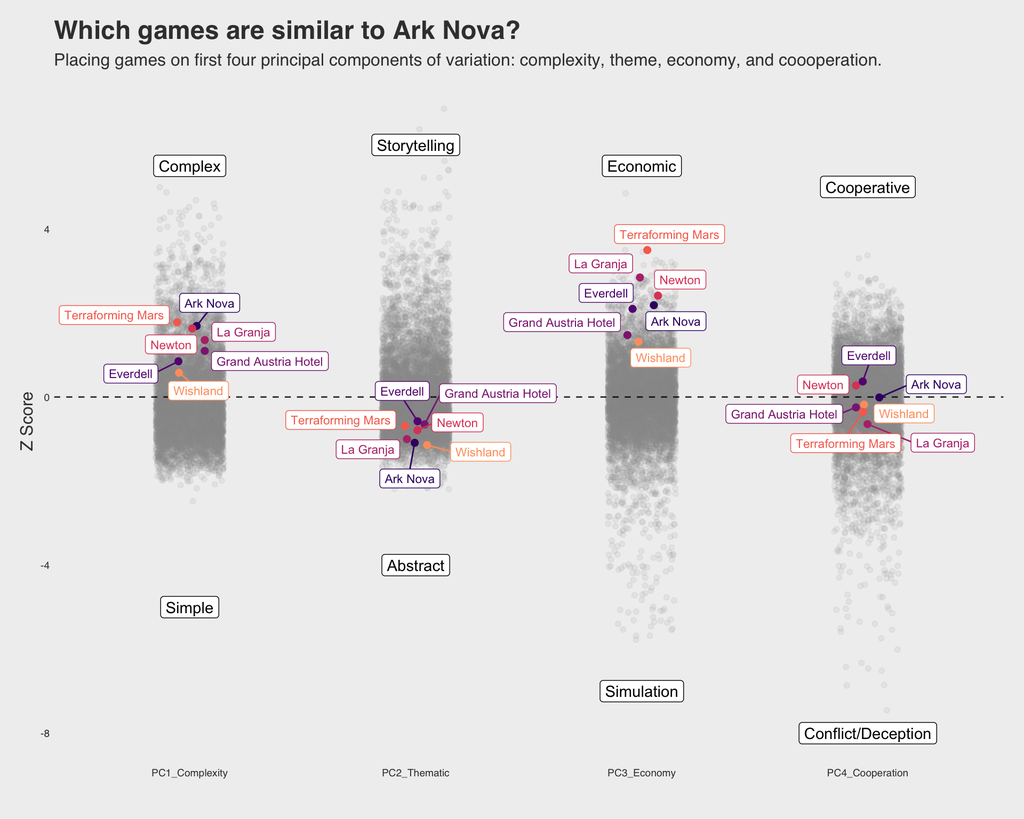